# Muestreo por rebanadas (slice sampling)

Recordemos que el teorema fundamental de la simulación nos dice que

$$ X\sim \mathcal{L}(f(x)) \iff (X,U)\sim \text{Uniforme}\left\{ (x,u) \, : \, 0<u<f(x) \right\} $$

con lo que se tienen las condicionales $$ U|X \sim \text{Uniforme}(0,f(X)) $$ y $$ X|U \sim \text{Uniforme}\left\{ x \, : \, U \leq f(x) \right\} $$

por lo que podemos implementar un muestreador de Gibbs al que llamamos muestreador por rebanadas (o slice).

#### Algoritmo de muestreo por rebanadas

Sea $U_{n-1}$ y $X_{n-1}$

1) Simule $U_n\sim \text{Uniforme}(0,f(X_{n-1}))$.

2) Simule $X_n \sim \text{Uniforme}\left\{ x \, : \, U_n \leq f(x) \right\}$

#### Ejemplo

Consideremos la función de densidad de probabilidad

$$ f(x) = \frac{1}{2}e^{-\sqrt{x}}\pmb{1}\left\{ x \geq 0 \right\} $$

entonces para $X|U=u$ las rebanadas de las cuales se simula uniformente están dadas por

$$ \left\{ 0\leq x \, : \, u \leq \frac{1}{2}e^{-\sqrt{x}} \right\}= \left\{ 0\leq x \, : \, -\log(2u) \geq \sqrt{x} \right\}= \left\{ 0\leq x \, : \, \left( \log(2u) \right)^2 \geq x \right\} =\left[0,\left( \log(2u) \right)^2 \right] $$

entonces $$X|U\sim \text{Uniforme}\left(0, \left( \log(2u) \right)^2 \right).$$

```julia
n = 10000
u = zeros(Float64,n)
x = zeros(Float64,n)
u[1] =  rand(Uniform(0,f(0)))
x[1] = rand(Uniform(0,log(2*u[1])^2.0))
for i in 2:n
    u[i] = rand(Uniform(0,f(x[i-1])))
    x[i] = rand(Uniform(0,log(2*u[i])^2.0))
end
```

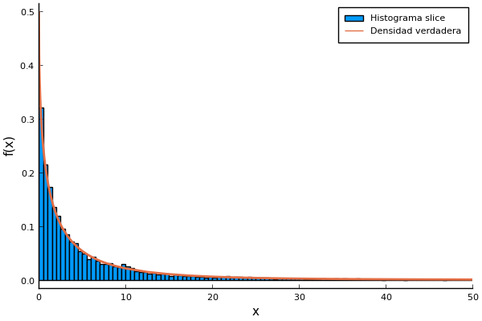

```julia
plot(p)
```

Si consideramos una función de densidad de probabilidad

$$ f(x) \propto \prod_{i=1}^k f_i(x) $$

podemos expresar

$$ f_i(x) = \int \pmb{1}\left\{ 0 \leq w_i \leq f_i(x) \right\} \mathrm{d}w_i $$

y tomar $(x,w_1,\ldots , w_k)\sim \mathcal{L}\left( p \right)$ con

$$ p(x,w_1,\ldots , w_k) \propto \prod_{i=1}^k \pmb{1}\left\{ 0 \leq w_i \leq f_i(x) \right\} $$

#### Algoritmo general de muestreo por rebanadas

Sea $W_{1,n-1},\ldots , W_{k,n-1}$ y $X_{n-1}$

1) Simule $W_{1,n-1} \sim \text{Uniforme}(0,f_1(X_{n-1}))$.

$\vdots$

k) Simule $W_{k,n-1} \sim \text{Uniforme}(0,f_k(X_{n-1}))$.

k+1) Simule $X_n \sim \text{Uniforme}\left\{ x \, : \, W_{i,n} \leq f_i(x),\; 1\leq i \leq k \right\}$

#### Ejemplo

Consideremos

$$ f(x) \propto \left( 1 + \sin^2(3x) \right) e^{-x^2/2} $$

entonces podemos tomar $f_1(x)=\left( 1 + \sin^2(3x) \right)$ y $f_2(x)=e^{-x^2/2}$. Tenemos

$$ \left\{ x \, : \, w_1 \leq 1 + \sin^2(3x) \right\}=\begin{cases} \bigcup_{k\in\mathbb{N}} \left( \frac{ \arcsin\left(\sqrt{w_1 -1}\right) }{3} + \frac{k}{3}\pi , \frac{ \pi - \arcsin\left(\sqrt{w_1 -1}\right) }{3} + \frac{k}{3}\pi \right) & \text{ si } w_1 \geq 1 \\ \mathbb{R} & \text{ si }w_1 < 1 \end{cases} $$

y

$$ \left\{ x \, : \, w_2 \leq e^{-x^2/2} \right\}= \left[ -\sqrt{- 2\log(w_2)}, \sqrt{- 2\log(w_2)} \right] $$

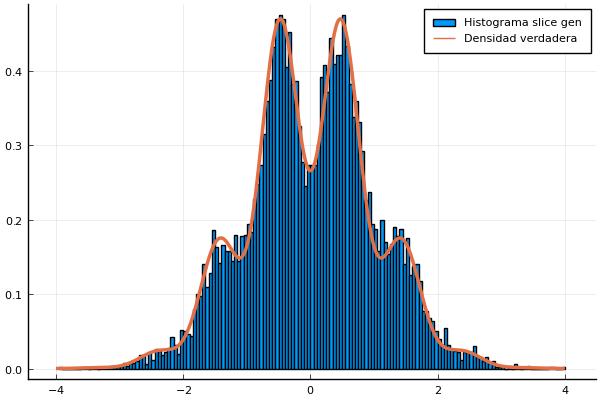

```julia
plot(p)
```

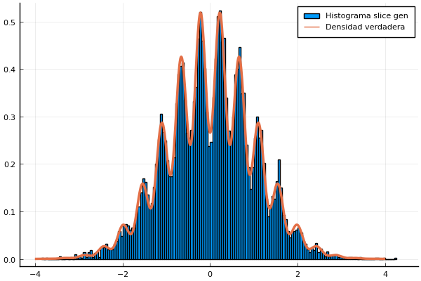

```julia
plot(p)
```

Cuando una densidad no puede ser factorizada ni invertida para obtener de manera relativamente sencilla las rebanadas horizontales, podemos construir rebanadas aleatorias $[L,R]$ que contengan casi seguramente a la rebanada horizontal desconocida. De esta manera podemos simular uniformennte de $[L,R]$ y aceptar cuando el punto generado pertenezca a la rebanada horizontal deseada. Para justificar que tal procedimiento conforma un MCMC debemos tener especial cuidado en no "romper" la reversibilidad del muestreo por rebanadas (caso particular del muestreo de Gibbs).

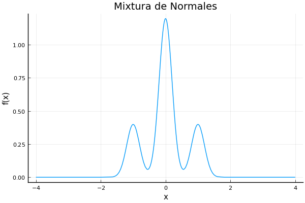

```julia
plot(p)
```

## Algoritmo Slice Stepout

1) Elija un punto incial $x_0$, $w$ una longitud supuesta para la rebanada, $m$ un enetero para limitar el grosor de la rebanada y $y$ el nivel vertical definiendo la rebanada.

2) Sean $U,V\sim \text{Uniforme}(0,1)$ independientes.

3) Tome $L=x_0 - wU$, $\,R=x_0 + w(1-U)$, $\,J=\lfloor mV\rfloor\,$ y $\,K=m-1-J$

4) Mientras $J>0\,$ y $\,y<f(L)$.

4.a) Actualice $L=L-w\,$ y $\,J=J-1$.

5) Mientras $K>0\,$ y $\,y<f(R)$.

5.a) Actualice $R=R+w\,$ y $\,K=K-1$.

## Algoritmo Slice Doubling

1) Elija un punto incial $x_0$, $w$ una longitud supuesta para la rebanada, $m$ un enetero para limitar el grosor de la rebanada y $y$ el nivel vertical definiendo la rebanada.

2) Sean $U \sim \text{Uniforme}(0,1)$ independientes.

3) Tome $L=x_0 - wU$, $R=x0 + w(1-U)$ y $K=p$

4) Mientras $K>0$ y $\left\{ y<f(L)\, \text{ ó } \,y<f(R) \right\}$.

4.a) $V \sim \text{Uniforme}(0,1)$ Si $V<0.5$ actualice $L=L-(R-L)$ y en caso contrario $R=R+(R-L)$. Actualice $K=K-1$

## Algoritmo Shrinking

Sean $L$ y $R$ los extremos izquierdo y derecho, respectivamente, de la rebanada horizontal dada por $y\,$ y $\, x_0$ el valor aceptado en la rebanada anterior.

1) Tome $U\sim \text{Uniforme}(0,1)$ y $x_1=L+U(R-L)$.

2) Si $y<f(x_1)$ y, en caso de doubling, se acepta $x_1$ entonces termine el algoritmo. En caso contrario pase al paso 3).

3) Si $x_1 < x_0$ entonces tome $L=x_1$ y vuelva al paso 1), en caso contrario prosiga al paso 4).

4) Si $x_1 \geq x_0$ entonces tome $R=x_1$ y vuelva al paso 1).

1) Elija un punto incial $x_0$, $w$ una longitud supuesta para la rebanada, $m$ un enetero para limitar el grosor de la rebanada y $y$ el nivel vertical definiendo la rebanada.

2) Sean $U \sim \text{Uniforme}(0,1)$ independientes.

3) Tome $L=x0 - wU$, $R=x0 + w(1-U)$ y $K=p$

4) Mientras $K>0$ y $\left\{ y<f(L)\, \text{ ó } \,y<f(R) \right\}$.

4.a) $V \sim \text{Uniforme}(0,1)$ Si $V<0.5$ actualice $L=L-(R-L)$ y en caso contrario $R=R+(R-L)$. Actualice $K=K-1$

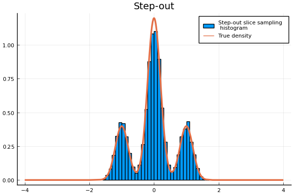

```julia
histogram(s_step[1000:end],normalize=true,label="Step-out slice sampling \n histogram")
plot!(f, -4, 4,linewidth=2.5,label="True density")
title!("Step-out")
```

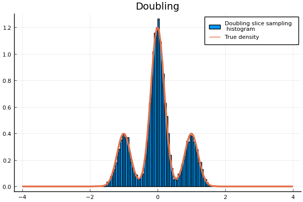

```julia
histogram(s_doub[1000:end],normalize=true,label="Doubling slice sampling \n histogram")
plot!(f, -4, 4,linewidth=2.5,label="True density")
title!("Doubling")
```

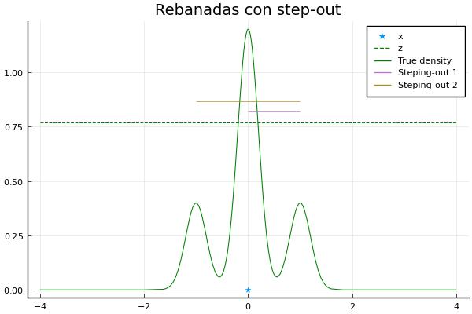

```julia
plot(p); title!("Rebanadas con step-out")
```

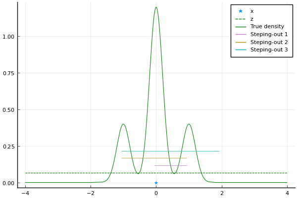

```julia
plot(p)
```

[figure not shown]

```julia
plot(p)
title!("Rebanadas con doubling")
```

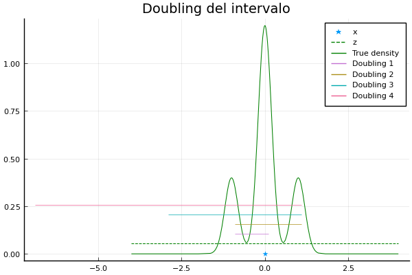

```julia
plot(p)
title!("Doubling del intervalo")
```

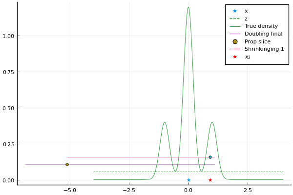

```julia
plot(p)
```

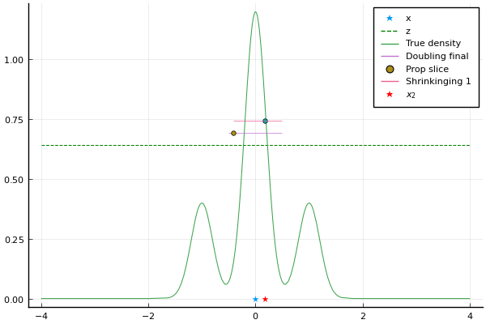

```julia
plot(p)
```

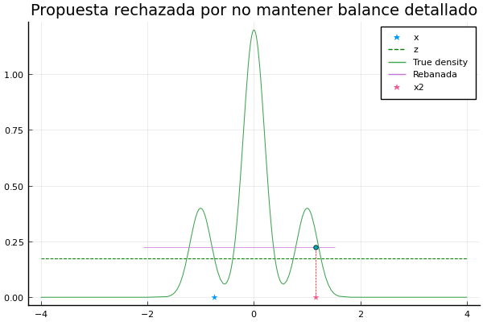

```julia
plot(p)
```

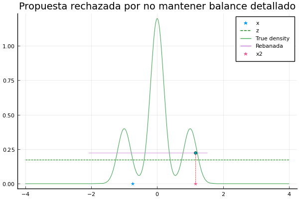

```julia
plot(p)
```